# Introducción al lenguaje R

Curso PyM

Autor: Luis Apáez Álvarez

Fecha: 08 de Enero del 2023

[figure not shown]

## Condicionales

Los condicionales corresponden a una estructura en la cual ejecutaremos una acción si cierta condición es verdadera, y ejecutaremos otra acción para el caso en que dicha condición sea falsa. Para entender de manera más sencilla la idea anterior, consideremos el siguiente ejemplo:

- Si el semáforo está en verde, entonces no cruzamos la calle. Tenemos en dicho ejemplo que la condición impuesta es “el semáforo está en verde”; si dicha condición es verdadera, entonces **no cruzamos la calle**; si dicha condición es falsa, **cruzaremos la calle**. De tal modo realizaremos alguna acción en caso de que la condición impuesta sea o no verdadera.

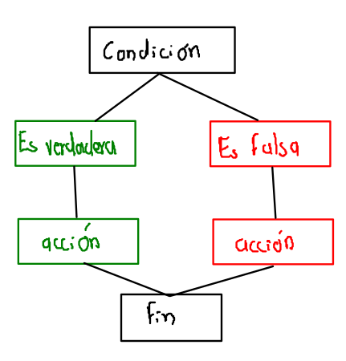

Así, con el ejemplo del semáforo tendríamos el siguiente diagrama

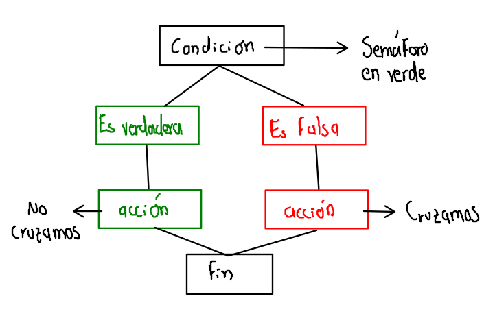

Podemos implementar condicionales en `R` siguiendo la siguiente estructura:

```
if (condicion) {
  acciones a realizar en caso de que la condicion
  sea verdadera
} else {
  acciones a realizar en caso de que la condicion
  sea verdadera
}
```

Continuando con nuestro ejemplo, escribimos

```r
# Condicion
semaforo_en_verde = TRUE

# Implementamos el condicional if
if (semaforo_en_verde) {
  # Accion a realizar en caso de que la condicion sea verdadera:
  # Imprimieremos un mensaje
  print("No cruzar")
} else {
  # Accion a realizar en caso de que la condicion sea falsa:
  # Imprimieremos un mensaje
  print("Puedes cruzar")
}
```

```
## [1] "No cruzar"
```

Dado que la condición impuesta es verdadera, entonces se ha impreso el mensaje `"No cruzar"`. Veamos ahora el resultado en caso de que la condición sea falsa

```r
# Condicion
semaforo_en_verde = F

# Implementamos el condicional if
if (semaforo_en_verde) {
  # Accion a realizar en caso de que la condicion sea verdadera:
  # Imprimieremos un mensaje
  print("No cruzar")
} else {
  # Accion a realizar en caso de que la condicion sea falsa:
  # Imprimieremos un mensaje
  print("Puedes cruzar")
}
```

```
## [1] "Puedes cruzar"
```

Así:

```r
# Identificador de numeros pares e impares.
# Definimos el numero n:
n = 7

# Implementamos un condicional
if (n %% 2 == 0) {
  print("El número considerado es par")
} else {
  print("El número considerado es impar")
}
```

```
## [1] "El número considerado es impar"
```

donde el símbolo `==` significa igualdad, pues recordemos que el símbolo `=` significa asignación. Luego, la condición `n %% 2 == 0` puede leerse como: el residuo de dividir n entre 2 es igual a 0. Lo anterior puede ser verdadero o falso, según sea el valor de $n$, lo cual nos arrojará un booleano (`FALSE` o `TRUE`), y con base a él ejecutaremos la acción en caso de que la condición sea verdadera o falsa. Podemos probar el código anterior con diferentes números de `n`

```r
# Identificador de numeros pares e impares.
# Definimos el numero n:
n = 240

# Implementamos un condicional
if (n %% 2 == 0) {
  print("El número considerado es par")
} else {
  print("El número considerado es impar")
}
```

```
## [1] "El número considerado es par"
```

o también

```r
# Identificador de numeros pares e impares.
# Definimos el numero n:
n = 1179

# Implementamos un condicional
if (n %% 2 == 0) {
  print("El número considerado es par")
} else {
  print("El número considerado es impar")
}
```

```
## [1] "El número considerado es impar"
```

veamos que, cada que queremos utilizar el código para determinar si un número `n` es par o impar, debemos de escribir de nuevo todo el código del condicional, lo cual no es lo óptimo. Para este tipo de situaciones donde queremos utilizar un **mismo código** para diferentes valores de una variable, en este caso de la `n`, podemos implementar el concepto de *Función definida por el usuario*.

## Vistazo rápido a las funciones

Dentro de `R` existen muchas funciones ya integradas, por ejemplo

```r
# Funcion sample
sample(1:10, 20, replace = T)
```

```
##  [1]  3  6  2  3  4  6  3  2  3  2  3  6  2  3  9  7  5  1 10  8
```

```r
# Funcion para crear un vector c()
v1 <- c(1:100)

# Funcion para calcular el promedio de un vector
mean(v1)
```

```
## [1] 50.5
```

etcétera. Asimismo, podremos definir nuestras propias funciones. Para ello utilizaremos la siguiente estructura:

```r
nombre_de_la_funcion <- function(<<parametros>>){
  <<acciones que realiza la funcion>>
  return(<<valores que regresa la funcion>>)
}
```

Por ejemplo, en nuestro caso queremos definir una función que, dado un número `n`, nos diga si el número es par o impar. De tal manera escribimos:

```r
# Definimos nuestra primera funcion
par_impar <- function(n){

  # Implementamos un condicional
  if (n %% 2 == 0) {

    return("El número considerado es par")

  } else {

    return("El número considerado es impar")

  }
}
```

donde, dado un valor de `n`, la función nos regresará un mensaje diciéndonos si el número es par o impar. Algo que es importante de mencionar es que, dentro de `R` la identación o el “sangrado” de las líneas de código es importante

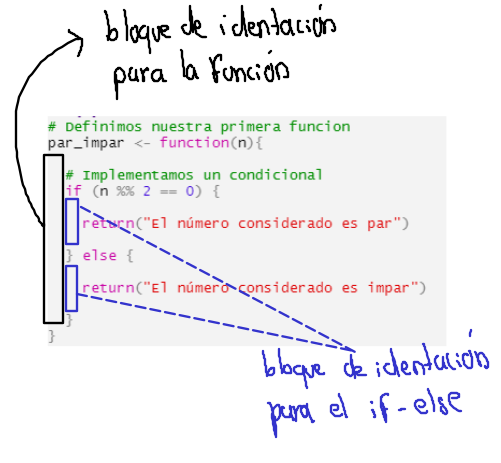

Esto es, cada estructura en `R` tiene su propio nivel de identación, además, podemos anidar estructuras (así como lo hicimos colocando dentro de la función un condicional)

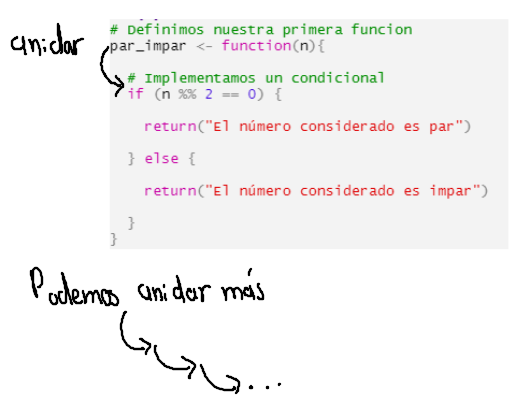

Las funciones definidas por el usuario son realmente flexibles y versátiles, lo que nos permite definir muchas, muchas, cosas. Por ejemplo:

```r
# Definimos una funcion que calcule el promedio de un vector
mi_promedio <- function(vector){
  # Calculamos la suma de las entradas del vector
  suma = sum(vector)
  # Calculamos el numero total de entradas del vector
  n = length(vector)
  # Regresamos el promedio del vector
  return(suma / n)
}

# Probemos la funcion:
mi_promedio(c(1,2,3,4,5))
```

```
## [1] 3
```

```r
# Comprobamos
mean(c(1,2,3,4,5))
```

```
## [1] 3
```

Con esta misma idea, podemos definir, tal cual, funciones matemáticas. Por ejemplo, considerando la función $f(x)=x^{2}$, escribimos

```r
# Definiendo funciones matematicas
f <- function(x){
  return(x ** 2)
}

# Probamos la funcion para distintos valores
f(0)
```

```
## [1] 0
```

```r
f(-5)
```

```
## [1] 25
```

```r
f(25)
```

```
## [1] 625
```

Podemos definir una función que calcule al área de un círculo dependiendo el valor del radio:

```r
area_circ <- function(r){
  return(pi * r ^ 2)
}

# Probamos la funcion
area_circ(5)
```

```
## [1] 78.53982
```

donde

```r
pi
```

```
## [1] 3.141593
```

nos da el valor del número $\pi$.

Para finalizar, notemos que, dado un vector, podemos acceder de manera individual a cada uno de sus elementos. Por ejemplo

```r
# Definimos un vector
vc <- seq(0, 10, by=2)
vc
```

```
## [1]  0  2  4  6  8 10
```

donde el `0` está en la **primera posición** del vector; el `2` está en la **segunda posición**; el `4` está en la **tercera posición**; y así sucesivamente. Podremos acceder a los elementos de un vector utilizando, el nombre del vector, y corchetes como sigue

```r
# Elemento en la primera posicion
vc[1]
```

```
## [1] 0
```

```r
# Elemento en la segunda posicion
vc[2]
```

```
## [1] 2
```

```r
# Elemento en la quinta posicion
vc[5]
```

```
## [1] 8
```

Adicionalmente, podemos obtener ciertos elementos del vector

```r
# Obtendremos los elementos de la posicion 1 a la posicion 3
vc[1:3]
```

```
## [1] 0 2 4
```

## Bucles

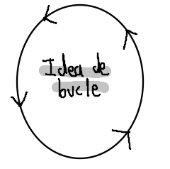

Los bucles son estructuras que nos permiten realizar cierta acción de manera repetida. Principalmente tendremos dos tipos de bucles: el bucle `for` y el bucle `while`.

- El bucle `for` nos permitirá repetir una acción *un determinado número de veces*.
- El bucle `while` nos permitirá repetir una acción *mientras cierta condición sea verdadera*.

### Bucle `for`

Como su nombre lo indica, el bucle `for` representa un proceso repetitivo, donde ciertas instrucciones se estarán **repitiendo un número determinado de veces**. Por ejemplo, consideremos un vector e imprimamos cada uno de sus elementos

```r
# Vector con entradas de varios tipos de datos
vect2 <- c(10, 'nombre', FALSE)
# Podemos imprimir el PRIMER ELEMENTO del vector anterior colocando entre corchetes el numero 1
print(vect2[1])
```

```
## [1] "10"
```

```r
# Imprimimos el segundo elemento
print(vect2[2])
```

```
## [1] "nombre"
```

```r
# Imprimimos el tercer elemento
print(vect2[3])
```

```
## [1] "FALSE"
```

Supongamos que tenemos un vector con 100 entradas y queremos imprimir cada una de ellas. Si realizamos el mismo proceso anterior pero ahora para el vector de 100 entradas, tardaremos un tiempo considerable. Como alternativa podemos utilizar un bucle `for` cuya estructura básica es:

```
for (recorrido) {
  acción a repetir
}
```

Lo que haremos será imprimir cada uno de los elementos del vector `vect2` utilizando un bucle `for`. Notamos que dicho vector tiene en total 3 elementos, de modo que necesitaremos crear un vector:

```r
# Creamos un vector
vect_recorrido <- 1:3
vect_recorrido
```

```
## [1] 1 2 3
```

el cual tiene los elementos que ocupamos para acceder a todos los elementos del vector `vect2`. Luego implementamos el `for`

```r
for (i in vect_recorrido){

  # Accion a ejecutar repetidamente
  print(vect2[i])

}
```

```
## [1] "10"
## [1] "nombre"
## [1] "FALSE"
```

donde la `i` es una variable propia del bucle `for` (y en realidad puede llamarse como sea). La variable del `for` recorrerá cada elemento del vector `vect_recorrido` de la siguiente manera:

- Inicialmente en el bucle la `i` vale 1 (que es el primer valor del vector `vect_recorrido`) y así se ejecuta la acción `print(vect2[i])`, pero `i` vale 1, por lo cual se ejecuta `print(vect2[1])`, lo que nos arroja `"10"`.
- Luego, la `i` vale 2 (que es el segundo elemento del vector `vect_recorrido`) y por ello se ejecuta `print(vect2[2])` que nos arroja `"nombre"`.
- Finalmente se ejecuta ```print(vect2[3])` que nos arroja `"FALSE"`.

El bucle finaliza cuando la `i` recorre todos los elementos de `vect_recorrido`. Veamos una alternativa del código anterior

```r
# directamente colocamos la secuencia del 1 al 3
for (i in 1:3){
  # Accion a ejecutar repetidamente
  print(vect2[i])
}
```

```
## [1] "10"
## [1] "nombre"
## [1] "FALSE"
```

o también

```r
# directamente colocamos la secuencia del 1 al 3
for (i in 1:length(vect2)){
  # Accion a ejecutar repetidamente
  print(vect2[i])
}
```

```
## [1] "10"
## [1] "nombre"
## [1] "FALSE"
```

Asimismo, directamente podemos recorrer los elementos del vector `Vect2` sin la necesidad de acceder a las posiciones con los corchetes:

```r
# Recorremos directamente los elementos de vect2
for (i in vect2){
  # Accion a ejecutar repetidamente
  print(i)
}
```

```
## [1] "10"
## [1] "nombre"
## [1] "FALSE"
```

donde en este caso:

- Al inicio la `i` tomará el valor de `"10"`.
- En la siguiente iteración la `i` tomará el valor de `"nombre"`.
- Finalmente la `i` tomará el valor de `"FALSE"` y el bucle termina.

Veamos un ejemplo práctico. Lo que haremos será definir un vector sin elementos, y en éste le iremos agregando únicamente los números pares en el rango del 1 al 50:

```r
# Definimos un vector con la secuencia de numeros del 1 al 50
secuencia <- 1:50

# definimos un vector vacio para ir almacenando los numeros pares
pares <- c()

# Implementamos el for que recorrera cada uno de los numeros de la secuencia anterior
for (i in secuencia){
  # Utilizaremos un condicional para detectar los numeros pares
  if (i %% 2 == 0){
    # Si i es par, lo agregamos a la lista pares
    pares = append(pares, i)
  }
}
# Veamos
pares
```

```
##  [1]  2  4  6  8 10 12 14 16 18 20 22 24 26 28 30 32 34 36 38 40 42 44 46 48 50
```

donde:

- Con el bucle `for` recorrimos todos los elementos del 1 al 50.
- Con el condicional `if` filtramos solo los numeros pares. Dichos paremos los agregamos a la lista pares `append(pares, i)`, pero para guardar la lista paremos con los elementos nuevos debemos estar actualizando la variable `pares`, por lo cual escribimos `pares = append(pares, i)`.
- El bucle funciona de la siguiente manera:
  - En la primera iteración la `i` vale 1, como el 1 no es par, entonces pasamos a la siguiente iteración.
  - En la siguiente iteración la `i` vale 2, como el dos es par, entonces `append(pares, i)` resulta en el vector `c(2)`. Para guardar ese vector resultanto lo almacenamos en la variable `pares`.
  - En la cuarta iteración la `i` vale 4, de modo que `append(pares, i)` resulta en el vector `c(2, 4)` y guardamos ese vector en la variable `pares`.
  - Y así sucesivamente.

Recordemos que definimos la función $f(x)=x^{2}$. Podemos evaluar con distintos valores de la $x$ utilizando un bucle `for`

```r
# Evaluamos la funcion para los numeros del -5 al 5
for (x in seq(-5,5)) {
  print(f(x))
}
```

```
## [1] 25
## [1] 16
## [1] 9
## [1] 4
## [1] 1
## [1] 0
## [1] 1
## [1] 4
## [1] 9
## [1] 16
## [1] 25
```

### Bucle `while`

El bucle `while` es muy similar al `for`. El bucle `for` repite instrucciones un número determinado de veces, pero el bucle `while` repetirá la instrucción **mientras una condición sea verdadera**. Cuando dicha condición impuesta sea falsa, el bucle `while` finalizará. La estructura básica es

```
while (condicion) {
  acción a repetir mientras la condicion sea verdadera
}
```

Debemos ser cuidadosos con el bucle `while` pues si la condición que imponemos nunca sea falsa, entonces, en teoría, el bucle `while` tampoco se detendrá. Así, dentro del código del `while` debemos escribir el código necesario para evitar que el bucle `while` sea “infinito”. Una de las tantas estrategias para hacer que el bucle `while` se detenga en cierto punto es utilizando la idea de un contador, por ejemplo

```r
contador = 0

# Implementamos el while imponiendo que la condicion a evaluar sea que el contador sea menor a 10
while (contador < 10) {
  # Imprimimos el valor del contador
  print(contador)

  # En cada iteracion aumentaremos un 1 el contador
  contador = contador + 1
}
```

```
## [1] 0
## [1] 1
## [1] 2
## [1] 3
## [1] 4
## [1] 5
## [1] 6
## [1] 7
## [1] 8
## [1] 9
```

en la última iteración tenemos que el contador vale 9, después se le sumará un 1 y por ello el valor se actualiza al 10. El bucle `while` evalúa `contador < 10`, donde en ese momento el contador vale 10, y como la condición es falsa, entonces el bucle se detiene.

Veamos otros ejemplos

```r
# Definimos la condicion del while
continuar = TRUE

# Definiremos un contador auxiliar
contador <- 0

while (continuar){
  # Imprimimos un mensaje
  print("Hola")

  # Aumentaremos en uno el contador
  contador = contador + 1

  # Implementamos un condicional para hacer que el
  # bucle no sea infinito
  if (contador == 3){
    continuar = FALSE
  }
}
```

```
## [1] "Hola"
## [1] "Hola"
## [1] "Hola"
```

donde:

- En la primer iteración la variable `continuar` es verdadera por lo que se ejecuta `print("hola")`. Aumentamos en uno el contador, por lo cual `contador` ahora vale 1. Luego, en el `if` vemos su `contador==3`, lo cual es falso pues ahora `contador` vale 1, de modo que `continuar` sigue siendo verdadera.
- En la segunda iteración `contador` vale 2 y de nuevo se ejecuta `print("hola")`.
- En la tercera iteración `contador` vale 3 y de nuevo se ejecuta `print("hola")`. Pero ahora `continuar==3` es verdadera, por lo cual se ejecuta la acción del condicional, así `continuar` ahora será falsa y por ende el bucle `while` finaliza. Es usual utilizar variables como contadores para hacer que el bucle `while` no sea infinito. Abordemos otro ejemplo

```r
# Definimos una variable inicial en 0
suma <- 0

# Definimos un contador
n <- 1

# Ejecutamos un bucle while mientras n sea menor o igual a 100
while (n <= 100){
  # En cada iteracion, a la variable suma le sumaremos el valor actual de la n
  suma = suma + n
  # aumentamos en 1 el valor de la n para que eventualmente el bucle se detenga
  n = n + 1
}

# Veamos el resultado final almacenado en la variable suma
suma
```

```
## [1] 5050
```

donde, con el código anterior hemos obtenido el resultado de

$$1+2+3+4+\cdots+100$$
donde dicha suma se suele denotar por $\sum_{i=1}^{100}i$, esto es:

$$\sum_{i=1}^{100}i=1+2+3+4+\cdots+100$$

Y así sucesivamente, lo cual nos da como resultado $\sum_{i=1}^{100}i=1+2+3+4+\cdots+100$. Podemos utilizar un bucle `while` para hallar el valor de

$$\sum_{i=1}^{100}(2\cdot i+4)=[2\cdot (1)+4]+[2\cdot (2)+4]+[2\cdot
(3)+4]+\cdots+[2\cdot (100)+4]$$
escribiendo

```r
# Definimos una variable inicial en 0
suma <- 0

# Definimos un contador
n <- 1

# Ejecutamos un bucle while mientras n sea menor o igual a 100
while (n <= 100){
  # En cada iteracion, a la variable suma le sumaremos el valor de 2*n + 4
  suma = suma + 2 * n + 4
  # aumentamos en 1 el valor de la n para que eventualmente el bucle se detenga
  n = n + 1
}

# Veamos el resultado final almacenado en la variable suma
suma
```

```
## [1] 10500
```

También podemos calcular

$$\sum_{i=1}^{100}i^{2}=1^{2}+2^{2}+\cdots+100^{2}$$
escribiendo

```r
# Definimos una variable inicial en 0
suma <- 0

# Definimos un contador
n <- 1

# Ejecutamos un bucle while mientras n sea menor o igual a 100
while (n <= 100){
  # En cada iteracion, a la variable suma le sumaremos el valor n al cuadrado
  suma = suma + (n ^ 2)
  # aumentamos en 1 el valor de la n para que eventualmente el bucle se detenga
  n = n + 1
}

# Veamos el resultado final almacenado en la variable suma
suma
```

```
## [1] 338350
```

Entro otros muchos ejemplos. Es preciso mencionar que, respecto a la notación, la $i$ de las sumas la representamos por la `n` del código, realmente no importa el nombre que le demos a la $i$ o a la `n`. No obstante, para que sea más concerde la notación, podemos escribir

```r
# Definimos una variable inicial en 0
suma <- 0

# Definimos un contador
i <- 1

# Ejecutamos un bucle while mientras n sea menor o igual a 100
while (i <= 100){
  # En cada iteracion, a la variable suma le sumaremos el valor n al cuadrado
  suma = suma + (i ^ 2)
  # aumentamos en 1 el valor de la n para que eventualmente el bucle se detenga
  i = i + 1
}

# Veamos el resultado final almacenado en la variable suma
suma
```

```
## [1] 338350
```

En resumen vemos que el funcionamiento del `while` y del `for` son muy similares.

## Ejercicios

1. Define una función que reciba como parámetro un número `n`. Luego, implementa dentro de dicha función un condicional que actúe de la siguiente manera: si el número `n` es mayor a 5, la función nos deberá regresar el mensaje `"El número que ingresaste es mayor a 5"`. Si el número es menor o igual a 5, entonces deberá regresar un mensaje indicando justamente eso.
2. Define una función para calcular el área de un cuadrado dependiendo la longitud de su lado.
3. Define una función de dos parámetros para calcular el área y el perímetro de un rectángulo. Para retornar el resultado deberás de utilizar `return(paste(...))`, donde en `paste(...)` deberás combinar cadenas de texto y los valores obtenidos del área y el perímetro.
4. Define una función que reciba como parámetros dos vectores y que retorne la unión por filas (u horizontal) de dichos vectores.
5. Define en código la función matemática $f(x)=3x^{3}+2x^{2}-1$.

**Observación:** Deberás probar todas las funciones que definas.

6. Calcula el valor de $\sum_{i=1}^{50}i^{3}$ y $\sum_{i=}^{50}(2\cdot i - 3)$, utilizando bucles `while`.
7. Crea un vector aleatorio de 20 entradas y recorre cada uno de sus elementos utilizando un bucle `for`.
8. Crea una función que reciba como parámetro un vector con entradas de números enteros (e.j. `c(1,2,3)`). Dentro de tu función define una lista vacía y mediante un bucle `for` recorre todos los elementos del vector que se ingresó como parámetro y agrega a la lista vacía que creaste aquellos números que sean pares. La función deberá regresar la lista con los números pares del vector que se ingresó.

El “esqueleto” de lo que se te pide en el ejercicio anterior es:

```r
tu_funcion <- function(vector_parametro){
  # Defines el vector vacio
  vect_vacio <- c()

  # Recorres el vector vector_parametro
  for (i in vector_parametro) {
    # con un if filtras los elementos del vector vector_parametro que sean numeros pares y los agregas al vector vacio
    if (condition) {
      # implementa el codico para hacer el filtro y agregar los pares al vector vect_vacio
    }
  }
  return(vect_vacio)
}
```